# What Did The Presidents Say at Their Inauguration?

Qingyuan Zhang

true

This notebook was prepared with the following environmental settings.

```r
print(R.version)
```

[output not shown]

The first step of the report is to use topic modeling on 58 inauguration addresses to get top words used across speeches.

[output not shown]

When you select a topic, what’s shown on the right hand side are red bars, which are indications of the total number of times that term appeared in that topic, and the blue bars are the overall frequency of that term within the entire corpus.

Presidential inaugurations are snapshots of U.S. history and tradition. It’s the first opportunity for elected leaders to struct his stuff surrounded by historic venues. We can see from above topic modeling that there’re several topics every presidents would say at their inauguration speeches. They would address the sagging morale and lack of confidence, be frank and honest about the realities of the economy and wars. America, Freedom, Economy, Government, Jobs, Equality, Reform are the core parts that construct every speech.

After getting the big picture of what topics all the 58 inaugurations would include, let’s take individuals into consideration. How’s inauguration change through time? Do inaugural represents the speakers? Take Obama and Trump for example, either president’s inaugural address should have strong emotional response, since Obama became the first ever black president, and Trump is the first president with absolutly no formal political background.

# Interactive visualize important words in individual speeches

```r
library(shiny)

shinyApp(
    ui = fluidPage(
      fluidRow(style = "padding-bottom: 20px;",
        column(4, selectInput('speech1', 'Speech 1',
                              speeches,
                              selected=speeches[5])),
        column(4, selectInput('speech2', 'Speech 2', speeches,
                              selected=speeches[9])),
        column(4, sliderInput('nwords', 'Number of words', 3,
                               min = 20, max = 200, value=100, step = 20))
      ),
      fluidRow(
        plotOutput('wordclouds', height = "400px")
      )
    ),

    server = function(input, output, session) {

      # Combine the selected variables into a new data frame
      selectedData <- reactive({
        list(dtm.term1=ff.dtm$term[ff.dtm$document==as.character(input$speech1)],
             dtm.count1=ff.dtm$count[ff.dtm$document==as.character(input$speech1)],
             dtm.term2=ff.dtm$term[ff.dtm$document==as.character(input$speech2)],
             dtm.count2=ff.dtm$count[ff.dtm$document==as.character(input$speech2)])
      })

      output$wordclouds <- renderPlot(height = 400, {
        par(mfrow=c(1,2), mar = c(0, 0, 3, 0))
        wordcloud(selectedData()$dtm.term1,
                  selectedData()$dtm.count1,
              scale=c(4,0.5),
              max.words=input$nwords,
              min.freq=1,
              random.order=FALSE,
              rot.per=0,
              use.r.layout=FALSE,
              random.color=FALSE,
              colors=brewer.pal(10,"Blues"),
            main=input$speech1)
        wordcloud(selectedData()$dtm.term2,
                  selectedData()$dtm.count2,
              scale=c(4,0.5),
              max.words=input$nwords,
              min.freq=1,
              random.order=FALSE,
              rot.per=0,
              use.r.layout=FALSE,
              random.color=FALSE,
              colors=brewer.pal(10,"Blues"),
            main=input$speech2)
      })
    },

    options = list(height = 600)
)
```

[output not shown]

# How the internet and social media change our president’s inaugural?

[figure not shown]

Trump’s Tweet

[figure not shown]

Stop Tweeeting Trump

Well, I guess everyone gets some sense of how social media changes the way people communicates. @POTUS is the official twitter account used by president, (and yes, we also have @FLOTUS run by the first lady). After Trump taking office at the White House, people all notice that he still insisting on keeping his personal twitter handle @realdonaldtrump and not using the @POTUS. Some commentators consider this as a sign that he is continuing on building his “personal brand” instead of speaking from “the office of the president”.

As inauguration speeches can be important, they are also easily forgotten. What’s the end words Trump used at his inaugural?

“Together, We Will Make America Strong Again. We Will Make America Wealthy Again. We Will Make America Proud Again. We Will Make America Safe Again. And, Yes, Together, We Will Make America Great Again. Thank you, God Bless You, and God Bless America.”

Trump’s contribution to the canon will be remembered for its brevity, pugnacity, and radical departure from precedent - much like the candidate (now president) himself.

So, why don’t we do an analysis on the lenght of sentences in the inaugural speeches, and see how the length president chose to use changes through time.

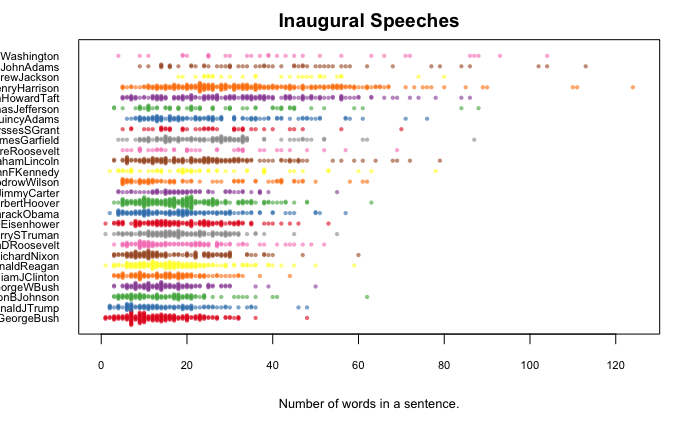

```r
mean(sentence.list.sel$word.count[sentence.list.sel$President=="Donald J. Trump"])
```

```
[1] 15.29474
```

Perhaps appropriate for a politician who’s mastered the art of the 140-character tweet, Trump spoke in short sentences - about 15 words per sentence, compared with Obama’s 2009 address, which averaged 19.

Let’s also look at the interactive bar chart for a more visual sense of how the length of inauguration speeches change across presidents.

[interactive chart not shown]

First let’s take a look at the outstanding 8460 words inaugural speech! William Henry Harrison, the ninth President of the united states, who was 68 years, 23 days old at the time of his inauguration delivered the speech. Another thing you may want to learn about this president who had the longest (2 hrs) inaugural address to date is that he died of complications from pnenumonia 31 days into his term, serving the shortest tenure in United States presidential history. He was the first president to die in office.

Then, back to our 45th President of the United States. From the plot we can get that Trump’s address was considerably shorter than both of his predecessors’ speeches, clocking in at just over 16 minutes. The speech was heavy on slogans and promises familiar from his campaign, stuffed with patriotic themes and free from the traditional arc, pacing, and rhetorical ambition of most modern inaugurals.

### It was uniquely Trumpian.

As he did during the campaign, Trump repurposed several famous phrases with tangled historical resonance and made them his own: “America first” and “forgotten man.”

Regarding to the immigration ban… Trump actually mentioned it in his inauguration speech, “From this day forward, a new vision will govern our land. From this day forward, it’s going to be only America First. America first. Every decision on trade, on taxes, on immigration, on foreign affairs, will be made to benefit American workers and American families. We must protect our borders from the ravages of other countries making our products, stealing our companies, and destroying our jobs.”

That’s all I want to talk with you about our president’s inauguration speeches. Okay, does the output of this report meet your expectation on some questions regarding our presidents?